# Census Income Project

STAVROS OIKONOMOU

### Loading the libraries

```r
ipak <- function(pkg){
  new.pkg <- pkg[!(pkg %in% installed.packages()[, "Package"])]
  if (length(new.pkg))
    install.packages(new.pkg, dependencies = TRUE)
  sapply(pkg, require, character.only = TRUE)
}

packages <- c("dplyr","tidyr","ggplot2","ROCR","corrplot","sparklyr","caret","missForest",
              "doParallel","R.utils","glmnet","coefplot","knitr","GGally")

ipak(packages)
```

```
##      dplyr      tidyr    ggplot2       ROCR   corrplot   sparklyr      caret
##       TRUE       TRUE       TRUE       TRUE       TRUE       TRUE       TRUE
## missForest doParallel    R.utils     glmnet   coefplot      knitr     GGally
##       TRUE       TRUE       TRUE       TRUE       TRUE       TRUE       TRUE
```

### Downloading and unziping the data

```r
temp <- tempfile()
if(!file.exists("./census-income.data.gz")){

    fileUrl <- "https://archive.ics.uci.edu/ml/machine-learning-databases/census-income-mld/census-income.data.gz"

    download.file(fileUrl, destfile = "./census-income.data.gz", mode="wb")
}

if(!file.exists("census-income.data")){
    gunzip("census-income.data.gz","census-income.data",remove=F)
}
rm(fileUrl)
```

```r
temp <- tempfile()
if(!file.exists("./census-income.test.gz")){

    fileUrl2 <- "https://archive.ics.uci.edu/ml/machine-learning-databases/census-income-mld/census-income.test.gz"

    download.file(fileUrl2, destfile = "./census-income.test.gz", mode="wb")
}

if(!file.exists("census-income.test")){
    gunzip("census-income.test.gz","census-income.test",remove=F)
}
rm(fileUrl2)
```

### Loading the databases

```r
df <- read.table("census-income.data", sep = ','
                 ,stringsAsFactors = TRUE ,na.strings = c(" ?", " Not in universe"))
df_test <- read.table("census-income.test", sep = ','
                      ,stringsAsFactors = TRUE,na.strings = c(" ?", " Not in universe"))
```

### Adding the column names

```r
colns <- c("Age","Class_of_Worker","Industry_code","occupation_code",
           "education","wage_per_hour","enrolled_in_edu_inst_last wk",
           "marital_status","major_industry_code","major_occupation_code","race",
           "hispanic_Origin","sex","member_of_a_labor_union","reason_for_unemployment",
           "full_part_time_employment_stat","capital_gains","capital_losses",
           "divdends_from_stocks","tax_filer_status","region_of_previous_residence",
           "state_of_previous_residence","detailed_household_and_family_stat",
           "detailed_household_summary_in_household","instance_weight",
           "migration_code-change_msa","migration_code-change_reg",
           "migration_code-move_within_reg","live_in_house_1_year_ago",
           "migration_prev_res_sunbelt","num_persons_worked_for_employer",
           "family_members_under 18","country_birth_father","country_birth_mother",
           "country_birth_self","citizenship","ownbusiness_or_self_employed",
           "fillinc_questionnaire_for_veterans_admin","veteran_benefits" ,
           "Weeks_worked_in_year", "Year", "Salary")

colnames(df) <- colns
colnames(df_test) <- colns
```

```r
head(df,3)
```

|  | Age | Class_of_Worker | Industry_code | occupation_code | education | wage_per_hour | enrolled_in_edu_inst_last wk | marital_status | major_industry_code | major_occupation_code | race | hispanic_Origin | sex | member_of_a_labor_union | reason_for_unemployment | full_part_time_employment_stat | capital_gains | capital_losses | divdends_from_stocks | tax_filer_status | region_of_previous_residence | state_of_previous_residence | detailed_household_and_family_stat | detailed_household_summary_in_household | instance_weight | migration_code-change_msa | migration_code-change_reg | migration_code-move_within_reg | live_in_house_1_year_ago | … |
| --- | --- | --- | --- | --- | --- | --- | --- | --- | --- | --- | --- | --- | --- | --- | --- | --- | --- | --- | --- | --- | --- | --- | --- | --- | --- | --- | --- | --- | --- | --- |
| 1 | 73 | NA | 0 | 0 | High school graduate | 0 | NA | Widowed | Not in universe or children | NA | White | All other | Female | NA | NA | Not in labor force | 0 | 0 | 0 | Nonfiler | NA | NA | Other Rel 18+ ever marr not in subfamily | Other relative of householder | 1700.09 | NA | NA | NA | Not in universe under 1 year old | … |
| 2 | 58 | Self-employed-not incorporated | 4 | 34 | Some college but no degree | 0 | NA | Divorced | Construction | Precision production craft & repair | White | All other | Male | NA | NA | Children or Armed Forces | 0 | 0 | 0 | Head of household | South | Arkansas | Householder | Householder | 1053.55 | MSA to MSA | Same county | Same county | No | … |
| 3 | 18 | NA | 0 | 0 | 10th grade | 0 | High school | Never married | Not in universe or children | NA | Asian or Pacific Islander | All other | Female | NA | NA | Not in labor force | 0 | 0 | 0 | Nonfiler | NA | NA | Child 18+ never marr Not in a subfamily | Child 18 or older | 991.95 | NA | NA | NA | Not in universe under 1 year old | … |

### Data Structure

```r
kable(str(df))
```

```
## 'data.frame':    199523 obs. of  42 variables:
##  $ Age                                     : int  73 58 18 9 10 48 42 28 47 34 ...
##  $ Class_of_Worker                         : Factor w/ 8 levels " Federal government",..: NA 6 NA NA NA 4 4 4 2 4 ...
##  $ Industry_code                           : int  0 4 0 0 0 40 34 4 43 4 ...
##  $ occupation_code                         : int  0 34 0 0 0 10 3 40 26 37 ...
##  $ education                               : Factor w/ 17 levels " 10th grade",..: 13 17 1 11 11 17 10 13 17 17 ...
##  $ wage_per_hour                           : int  0 0 0 0 0 1200 0 0 876 0 ...
##  $ enrolled_in_edu_inst_last wk            : Factor w/ 2 levels " College or university",..: NA NA 2 NA NA NA NA NA NA NA ...
##  $ marital_status                          : Factor w/ 7 levels " Divorced"," Married-A F spouse present",..: 7 1 5 5 5 3 3 5 3 3 ...
##  $ major_industry_code                     : Factor w/ 24 levels " Agriculture",..: 15 5 15 15 15 7 8 5 6 5 ...
##  $ major_occupation_code                   : Factor w/ 14 levels " Adm support including clerical",..: NA 8 NA NA NA 10 3 5 1 6 ...
##  $ race                                    : Factor w/ 5 levels " Amer Indian Aleut or Eskimo",..: 5 5 2 5 5 1 5 5 5 5 ...
##  $ hispanic_Origin                         : Factor w/ 10 levels " All other"," Central or South American",..: 1 1 1 1 1 1 1 1 1 1 ...
##  $ sex                                     : Factor w/ 2 levels " Female"," Male": 1 2 1 1 1 1 2 1 1 2 ...
##  $ member_of_a_labor_union                 : Factor w/ 2 levels " No"," Yes": NA NA NA NA NA 1 NA NA 1 NA ...
```

[output cut: 28 more lines]

[output not shown]

### Data Summary

```r
summary(df)
```

```
##       Age                               Class_of_Worker   Industry_code
##  Min.   : 0.00    Private                       : 72028   Min.   : 0.00
##  1st Qu.:15.00    Self-employed-not incorporated:  8445   1st Qu.: 0.00
##  Median :33.00    Local government              :  7784   Median : 0.00
##  Mean   :34.49    State government              :  4227   Mean   :15.35
##  3rd Qu.:50.00    Self-employed-incorporated    :  3265   3rd Qu.:33.00
##  Max.   :90.00   (Other)                        :  3529   Max.   :51.00
##                  NA's                           :100245
##  occupation_code                       education     wage_per_hour
##  Min.   : 0.00    High school graduate      :48407   Min.   :   0.00
##  1st Qu.: 0.00    Children                  :47422   1st Qu.:   0.00
##  Median : 0.00    Some college but no degree:27820   Median :   0.00
##  Mean   :11.31    Bachelors degree(BA AB BS):19865   Mean   :  55.43
##  3rd Qu.:26.00    7th and 8th grade         : 8007   3rd Qu.:   0.00
##  Max.   :46.00    10th grade                : 7557   Max.   :9999.00
##                  (Other)                    :40445
##          enrolled_in_edu_inst_last wk                          marital_status
##   College or university:  5688         Divorced                       :12710
##   High school          :  6892         Married-A F spouse present     :  665
##  NA's                  :186943         Married-civilian spouse present:84222
##                                        Married-spouse absent          : 1518
##                                        Never married                  :86485
##                                        Separated                      : 3460
##                                        Widowed                        :10463
##                          major_industry_code
##   Not in universe or children      :100684
##   Retail trade                     : 17070
##   Manufacturing-durable goods      :  9015
##   Education                        :  8283
##   Manufacturing-nondurable goods   :  6897
##   Finance insurance and real estate:  6145
##  (Other)                           : 51429
##                      major_occupation_code
##   Adm support including clerical: 14837
##   Professional specialty        : 13940
##   Executive admin and managerial: 12495
##   Other service                 : 12099
##   Sales                         : 11783
##  (Other)                        : 33685
##  NA's                           :100684
```

[output cut: 105 more lines]

```
##  Min.   :0.0000                No :  1593
##  1st Qu.:0.0000                Yes:   391
##  Median :0.0000               NA's:197539
##  Mean   :0.1754
##  3rd Qu.:0.0000
##  Max.   :2.0000
##
##  veteran_benefits Weeks_worked_in_year      Year            Salary
##  Min.   :0.000    Min.   : 0.00        Min.   :94.0    - 50000.:187141
##  1st Qu.:2.000    1st Qu.: 0.00        1st Qu.:94.0    50000+. : 12382
##  Median :2.000    Median : 8.00        Median :94.0
##  Mean   :1.515    Mean   :23.17        Mean   :94.5
##  3rd Qu.:2.000    3rd Qu.:52.00        3rd Qu.:95.0
##  Max.   :2.000    Max.   :52.00        Max.   :95.0
##
```

### Dimensions of train and test set

```r
dim(df)
```

```
## [1] 199523     42
```

```r
dim(df_test)
```

```
## [1] 99762    42
```

### Feature Selection

```r
nas <- inspectdf::inspect_na(df) #count percentage of NA's
todrop<-unlist(nas %>%
                 filter(pcnt>50) %>%
                 select(col_name)) # filtering features with NA percentage bigger than 50


near_zero_var <- nearZeroVar(df, freqCut = 99/1)
near_zero_var <- names(df)[near_zero_var] # finding variables with almost zero variance


df <- df %>%
  select(-c(todrop,near_zero_var))

df <- df %>%
  select(-instance_weight) # removing weight feature, we not gonna use it for prediction purposes

df <- df %>%  # same information with other variables
  select(-major_industry_code,-detailed_household_and_family_stat)

df <- df %>% # most of values are "nofiler"
  select(-tax_filer_status,-live_in_house_1_year_ago)
```

```r
registerDoParallel(cores=3)
dfn<- df %>%
  select(-Salary) %>%
  missForest(maxiter=1,ntree=10, variablewise=T, parallelize = "forests")
```

```
##   missForest iteration 1 in progress...done!
```

```r
df[,-20] <- dfn$ximp
```

## Data visualization and analysis

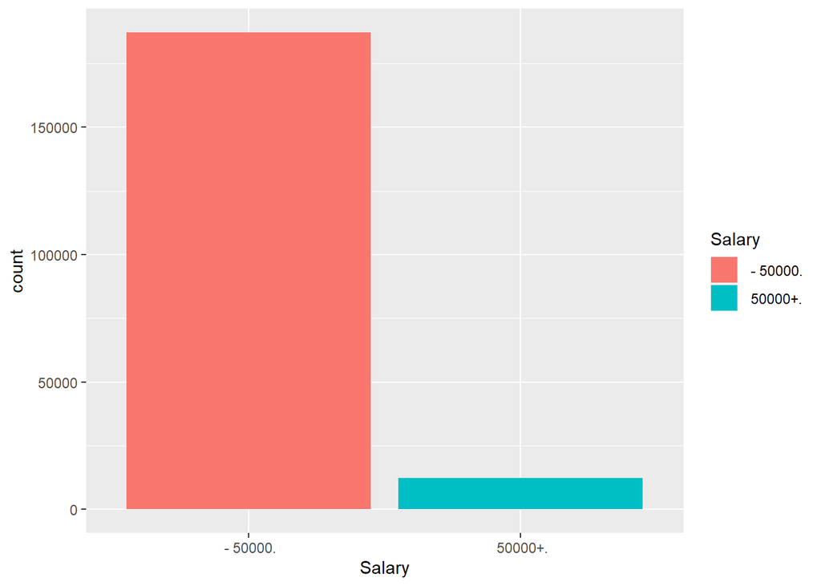

```r
ggplot(df, aes(x=Salary))+ geom_bar(aes(fill=Salary))
```

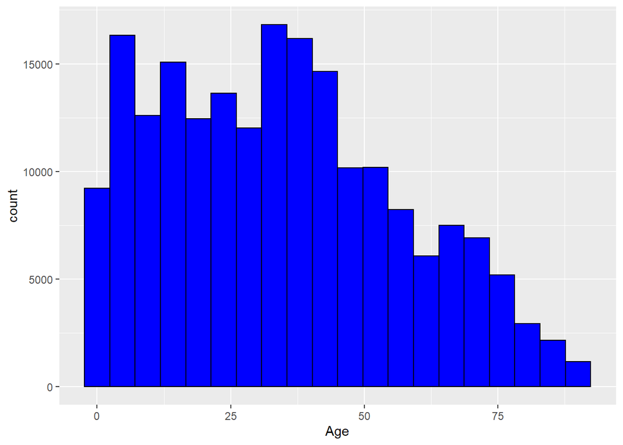

```r
ggplot(df, aes(x=Age))+ geom_histogram(aes(colour=I("black"), fill=I("blue")),bins=20)
```

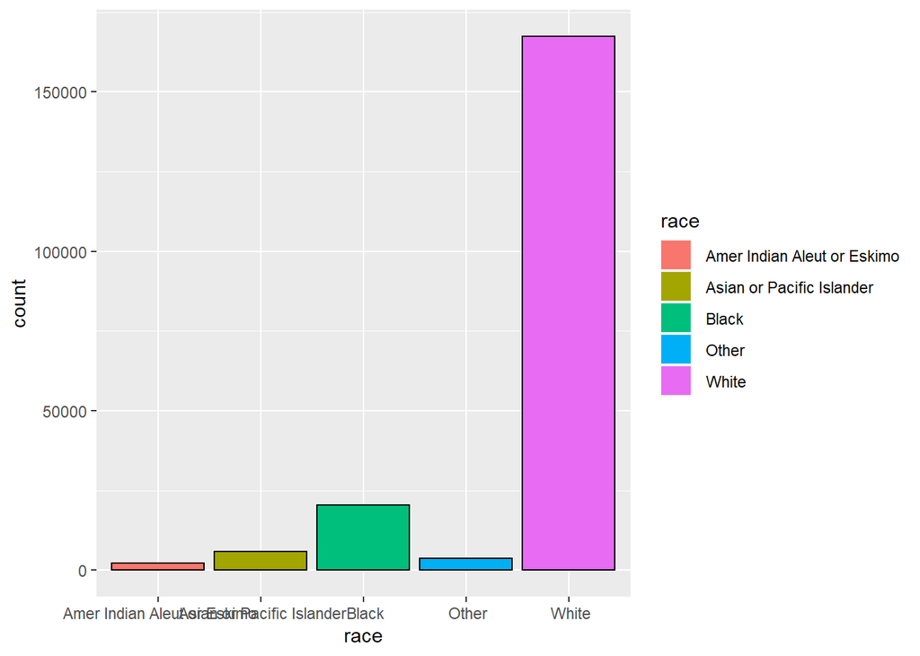

```r
ggplot(df, aes(x=race))+ geom_bar(aes( colour=I("black"), fill=race))
```

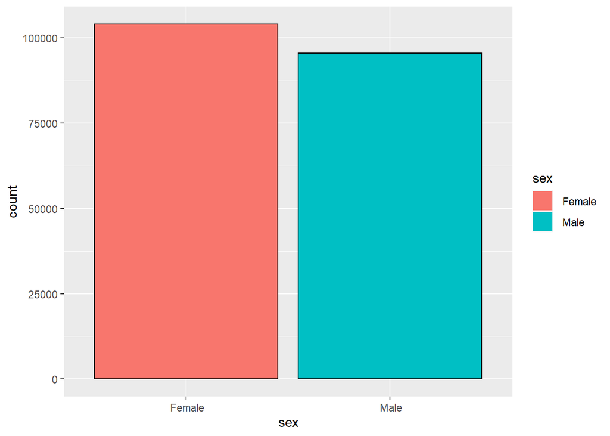

```r
ggplot(df, aes(x=sex))+ geom_bar(aes( colour=I("black"), fill=sex))
```

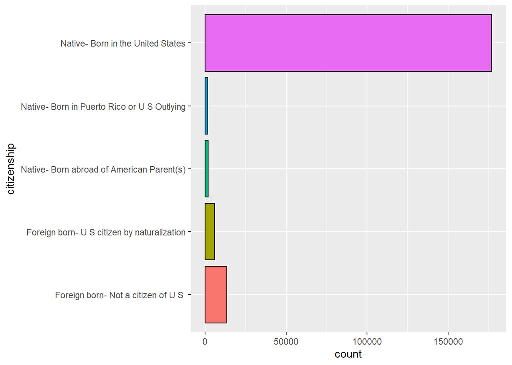

```r
ggplot(df, aes(x=citizenship))+ geom_bar(aes( colour=I("black"), fill=citizenship)) + coord_flip() + theme(legend.position = "none")
```

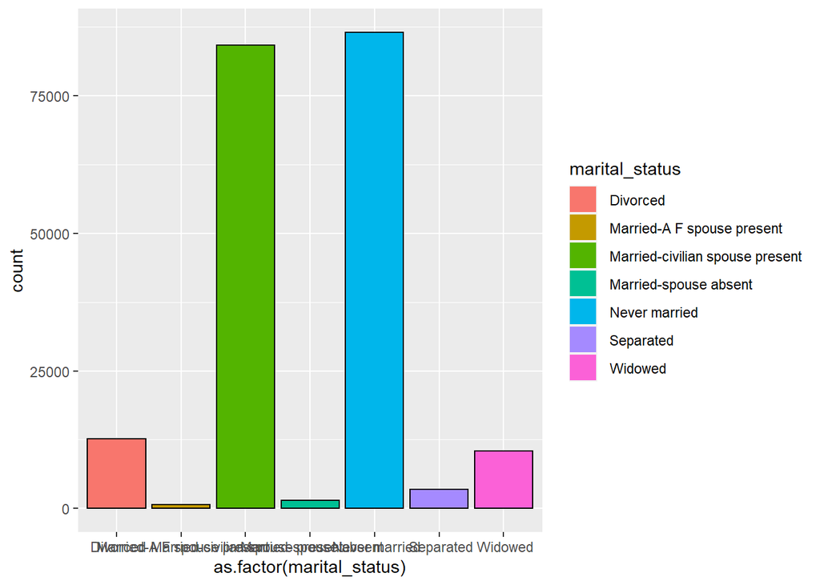

```r
ggplot(df, aes(x=as.factor(marital_status)))+ geom_bar(aes( colour=I("black"), fill=marital_status))
```

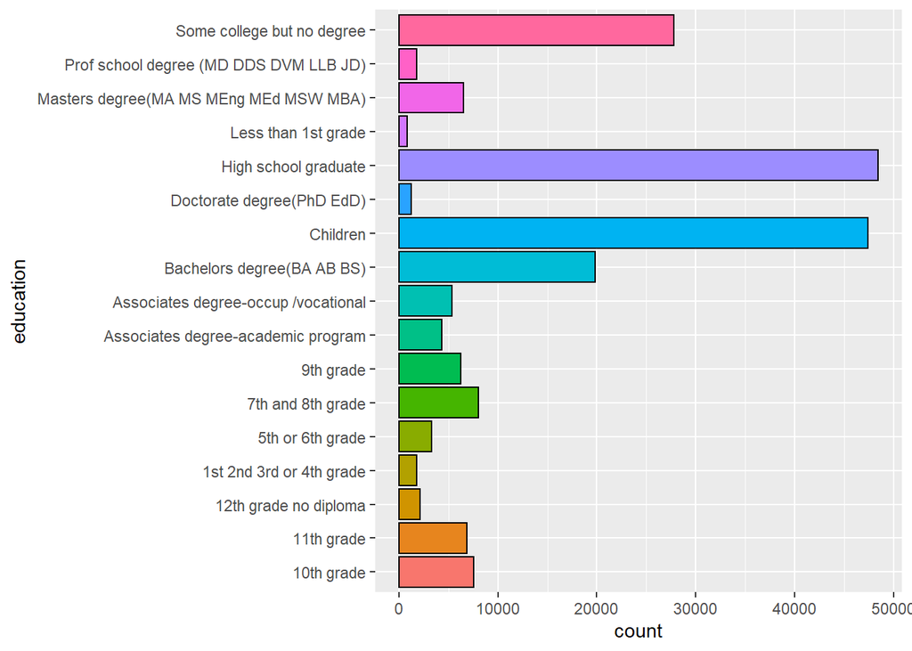

```r
ggplot(df, aes(x=education))+ geom_bar(aes( colour=I("black"), fill=education)) + coord_flip() + theme(legend.position = "none")
```

## Data correlations

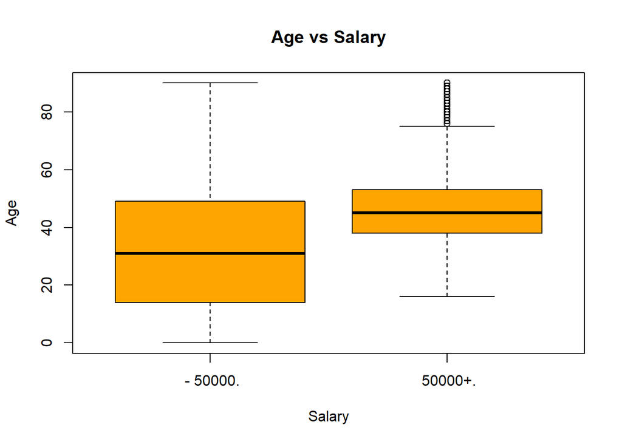

```r
boxplot(Age~Salary, data= df , main = "Age vs Salary",
        xlab = "Salary", ylab = "Age", col = "orange")
```

As we can see from the boxplot the age has important correlation with Salary. It looks like that you need to be older to earn more than 50.000.

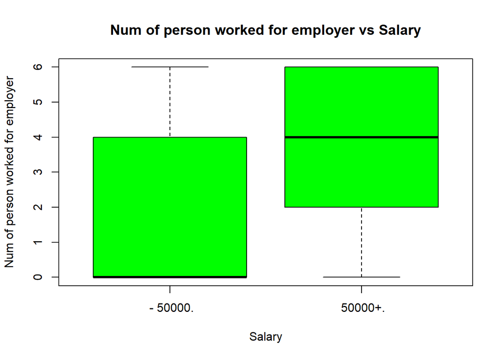

```r
boxplot(num_persons_worked_for_employer~Salary, data= df , main = "Num of person worked for employer vs Salary",
        xlab = "Salary", ylab = "Num of person worked for employer", col = "Green")
```

Working in a place with more employees seems to be important for Salary

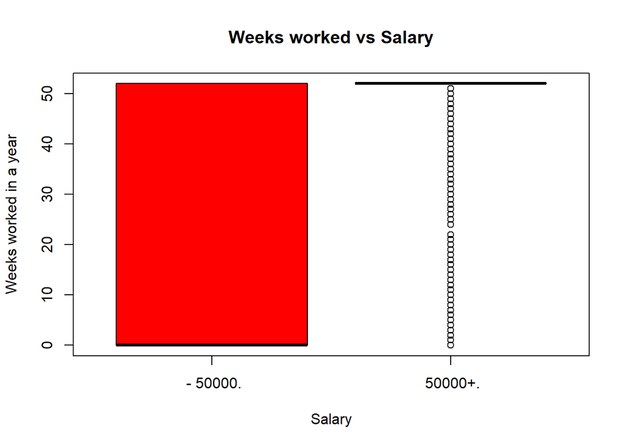

```r
boxplot(Weeks_worked_in_year~Salary, data= df , main = "Weeks worked vs Salary",
        xlab = "Salary", ylab = "Weeks worked in a year", col = "red")
```

Here we can see that in our database females are more than males but the males have significant more people earning more than 50.000. So we can see there is a correlation between sex and salary

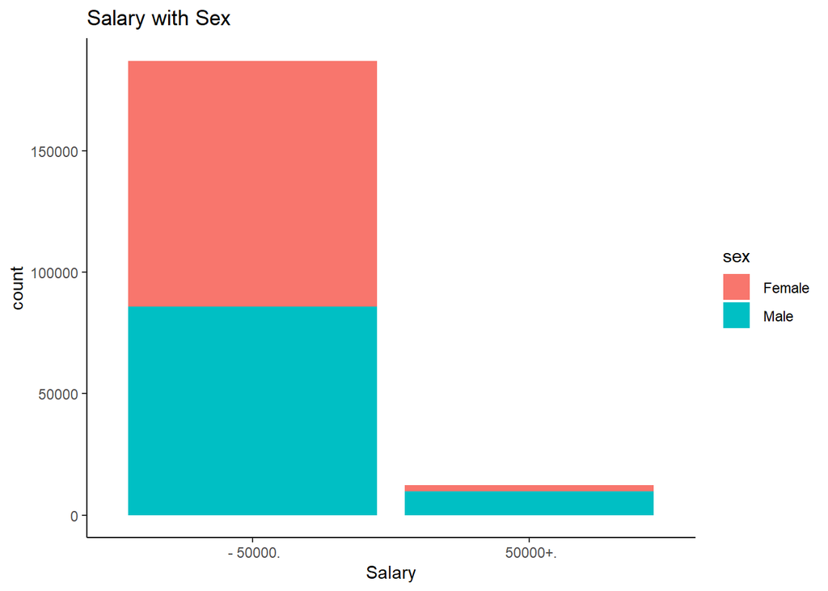

```r
ggplot(df, aes(x=as.factor(Salary))) + geom_bar(stat = "count", aes(fill=sex)) + xlab("Salary") + ggtitle("Salary with Sex") + theme_classic()
```

Race is also very important. it seems to be rare to earn more than 50k if you are not white.

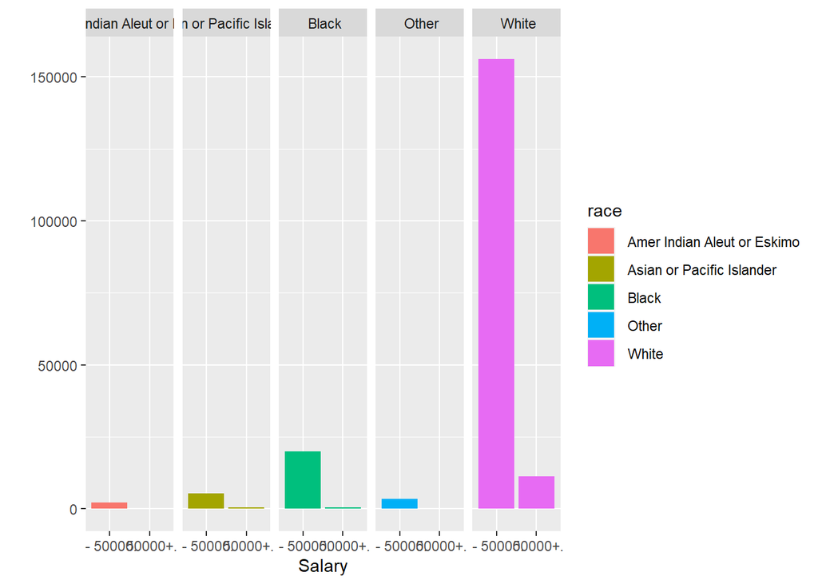

```r
qplot (Salary, data = df, fill = race) + facet_grid (. ~ race)
```

You need to have veteran benefits if you want to earn more than 50k

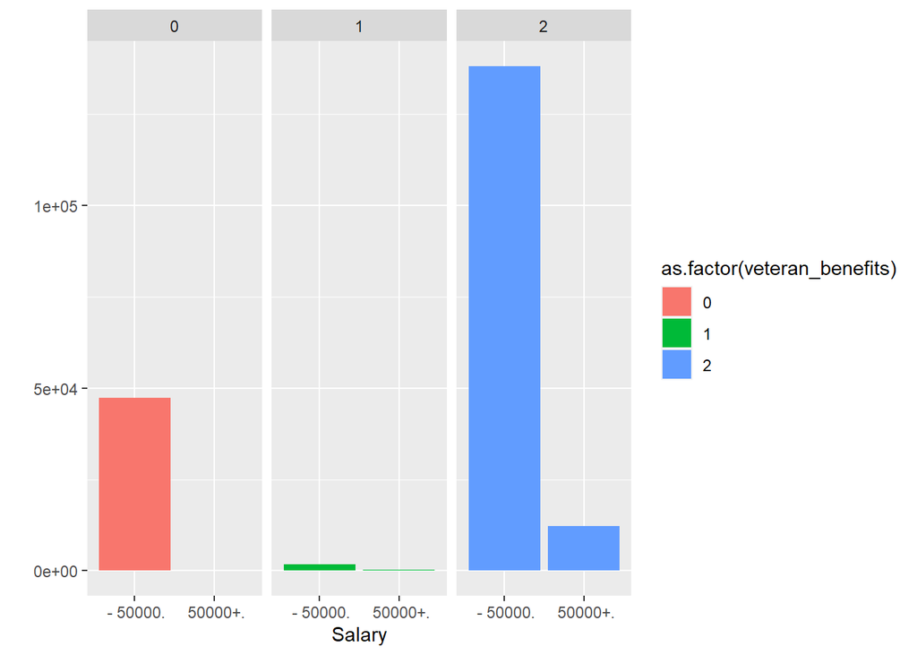

```r
qplot (Salary, data = df, fill = as.factor(veteran_benefits) ) + facet_grid (. ~ veteran_benefits)
```

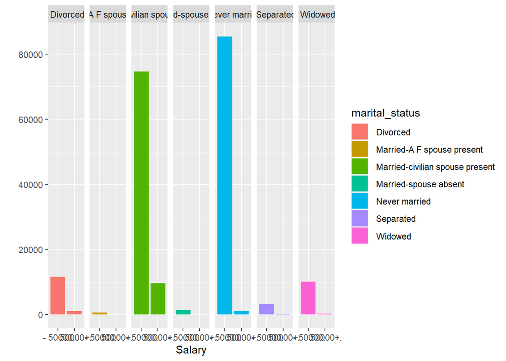

```r
qplot (Salary, data = df, fill = marital_status) + facet_grid (. ~ marital_status)
```

```r
df_test <- df_test %>% select(-c(todrop,near_zero_var,instance_weight,major_industry_code,
                                 detailed_household_and_family_stat,tax_filer_status,
                                 live_in_house_1_year_ago))
```

```r
registerDoParallel(cores=3)
dfnt<- df_test %>%
  select(-Salary) %>%
  missForest(maxiter=1,ntree=10, variablewise=T, parallelize = "forests")
```

```
##   missForest iteration 1 in progress...done!
```

```r
df_test[,-20] <- dfnt$ximp
```

## Binding the train and test database for feature engineering

#### Usually we need to split the data in train and test set after feature engineering, so we can avoid different kind of problems. One of the problems is that some times we have different number of levels or entries for train and test set regarding to the same feature. But this is not the correct strategy for all project, we always have to aware of data leakage

```r
df$train <- T
df_test$train <- F

df_total <- rbind(df,df_test)

df_total$Salary <- ifelse(df_total$Salary==" - 50000.",0,1)

df_total$race <- ifelse(df_total$race==" White", "White", "Not White")

df_total$hispanic_Origin <- ifelse(df_total$hispanic_Origin==" All other", 0, 1)

df_total$citizenship <- ifelse(df_total$citizenship %in%
                                 c(" Native- Born abroad of American Parent(s)",
                                   " Native- Born in Puerto Rico or U S Outlying",
                                   " Native- Born in the United States",
                                   " Foreign born- U S citizen by naturalization"),
                          "US citizenship", "No US citizenship")

levels(df_total$marital_status)[2:4] <- "Married"


levels(df_total$education)[levels(df_total$education) %in% c(" Children"," Less than 1st grade",
                                   " 1st 2nd 3rd or 4th grade",
                                   " 5th or 6th grade"," 7th and 8th grade",
                                   " 9th grade"," 10th grade"," 11th grade",
                                   " 12th grade no diploma" )] <- 0
levels(df_total$education)[levels(df_total$education) %in% c(" High school graduate",
                                                             " Some college but no degree")] <- 1
levels(df_total$education)[levels(df_total$education) %in%
                             c(" Associates degree-academic program",
                               " Prof school degree (MD DDS DVM LLB JD)",
                               " Associates degree-occup /vocational")] <- 2
levels(df_total$education)[levels(df_total$education)==" Bachelors degree(BA AB BS)"] <- 3
levels(df_total$education)[levels(df_total$education)==" Masters degree(MA MS MEng MEd MSW MBA)"] <- 4
levels(df_total$education)[levels(df_total$education)==" Doctorate degree(PhD EdD)"] <- 5


df_total <- df_total %>% mutate_if(is.character,factor)

vect <- c("Industry_code","occupation_code","num_persons_worked_for_employer",
          "ownbusiness_or_self_employed","Weeks_worked_in_year","Year","veteran_benefits")

df_total <- df_total %>% mutate_if(names(df_total) %in% vect, as.factor)
```

### Splitting the database to train and test set

```r
df_train <- df_total %>% filter(train==T) %>% select(-train)
df_test <- df_total %>% filter(train==F) %>% select(-train)
```

## Connecting to Spark

```r
sc <- spark_connect(master = "local")
```

### Connecting the datasets to Spark

```r
dfs_train <- sdf_copy_to(sc,df_train)
dfs_test <- sdf_copy_to(sc,df_test)
```

## GRADIENT BOOSTED TREE

```r
GBT_model <- dfs_train %>%
  ml_gbt_classifier(Salary~.)
GBT_pred <- ml_predict(GBT_model, dfs_test)
```

## AREA UNDER ROC

```r
GBT_pred2 <- ml_binary_classification_evaluator(GBT_pred)
GBT_pred2
```

```
## [1] 0.9239043
```

## Confusion Matrix

```r
cm <- table(pull(GBT_pred, label), pull(GBT_pred, prediction))
confusionMatrix(cm)
```

```
## Confusion Matrix and Statistics
##
##
##         0     1
##   0 92964   612
##   1  4646  1540
##
##                Accuracy : 0.9473
##                  95% CI : (0.9459, 0.9487)
##     No Information Rate : 0.9784
##     P-Value [Acc > NIR] : 1
##
##                   Kappa : 0.3485
##
##  Mcnemar's Test P-Value : <2e-16
##
##             Sensitivity : 0.9524
##             Specificity : 0.7156
##          Pos Pred Value : 0.9935
##          Neg Pred Value : 0.2489
##              Prevalence : 0.9784
##          Detection Rate : 0.9319
##    Detection Prevalence : 0.9380
##       Balanced Accuracy : 0.8340
##
##        'Positive' Class : 0
##
```

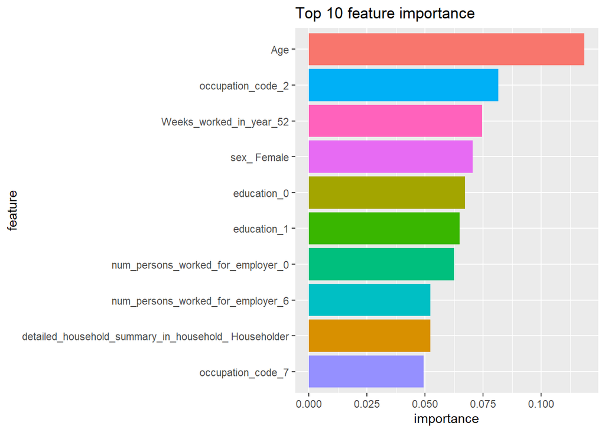

```r
featureImport <- ml_tree_feature_importance(GBT_model)
featureImport[1:10,] %>% ggplot(aes(reorder(feature, importance),importance,fill=feature)) +
  geom_bar(stat = "identity") + coord_flip() + ggtitle("Top 10 feature importance") +
  theme(legend.position="none") + ylab("importance") + xlab("feature")
```